# Hypothesis Testing

PSCI 2270 - Week 9

Georgiy Syunyaev

Department of Political Science, Vanderbilt University

October 24, 2024

## Plan for this week

1. Hypothesis testing
2. Discussion of two papers

# Hypothesis testing

## Answering questions with data

- **We conduct a thought experiment to see whether our results could have occurred by chance**
- Examples:
  - Biden’s support poll shows 40% now and it was 42% before. Did support decrease by 2% or could this purely by chance?
  - We encouraged random sample of people to go to protests and observe that their support for government policies is on average lower than among those who were not encouraged. Could this difference be produced by random chance?
- **Question: What would the world look like if we knew the truth?**
  - Sample mean is equal to $X$
  - Average treatment effect is $0$
  - Each individual effect is $0$
  - …

## Hypothesis testing

- **Hypothesis test:** (a) Assume some value other than what you observe is true, (b) determine what the data would look like in that world, (c) compare this to what you observe
1. Pose your null and alternative hypotheses
2. Generate the data assuming null is true OR say something about its distribution
3. Calculate a probability called a $p$-value by comparing outcomes under the null with what you observe
4. Use $p$-value to decide whether to reject the null hypothesis or not

## Null and alternative hypothesis

- **Null hypothesis:** Some statement about the population parameters.
  - The “devil’s advocate” hypothesis $\Rightarrow$ assumes what you seek to prove wrong
  - Ex: Biden’s approval is the same as election result
  - Ex: Treatment effect is zero for everyone
  - Denoted $H_0$
- **Alternative hypothesis:** The statement we hope or suspect is true instead of $H_0$.
  - It is the opposite of the null hypothesis
  - Ex: Biden’s approval fell
  - Ex: Treatment effect is different from zero (positive or negative)
  - Denoted $H_1$ or $H_a$
- **Probabilistic proof by contradiction:** Try to disprove the null

## Practicum example

- **Parameter:** Average Treatment Effect (ATE) $\mu_T - \mu_C$ of encouragement on support for government policies
  - $\mu_T$: Average support for government policies if everyone received encouragement
  - $\mu_T$: Average support for government policies if no one received encouragement
- **Goal:** Learn about the difference between average support for government policies between those who were encouraged and those who were not.
- **(Sharp) Null hypothesis:** No treatment effect for anyone
  - $H0$: $Y_i(1) - Y_i(0) = 0$ for all $i$
  - $H1$: $Y_i(1) - Y_i(0) \neq 0$ at least for some $i$ (Two-sided alternative)
  - In words: Does the treatment and control potential outcomes differ?
- **Other null hypothesis:** No **average** treatment effect

## $p$-value

- **$p$-value (based on a two-sided test):** Probability of getting an (absolute) difference in means this big (or bigger) **if the null hypothesis was true**
  - Lower $p$-values $\Rightarrow$ stronger evidence against the null
  - Intuition: How likely are we to observe what we observe if the null hypothesis is true?
- **Conclusion:** We either reject (if $p$-value is small) or **fail to reject** (if $p$-value is large) the null
- We never accept anything since the statement is probabilistic21

## RI: Observed Practicum Data

| Participant ID | $Z$ (Invited to protest) | $Y$ (Support for policies) | $Y (0)$ (Support for policies if not invited) | $Y (1)$ (Support for policies if invited) |
| --- | --- | --- | --- | --- |
| 1 | 1 | 0.859 | NA | 0.859 |
| 2 | 1 | 1.930 | NA | 1.930 |
| 3 | 1 | 0.875 | NA | 0.875 |
| 4 | 0 | 2.944 | 2.944 | NA |
| 5 | 0 | -1.015 | -1.015 | NA |
| 6 | 0 | -0.064 | -0.064 | NA |
| 7 | 0 | 1.624 | 1.624 | NA |
| 8 | 0 | -0.411 | -0.411 | NA |
| 9 | 1 | 1.048 | NA | 1.048 |
| 10 | 1 | -0.282 | NA | -0.282 |

- The observed difference in means is 0.2704
- For next step we need to reconstruct schedule of potential outcomes:
  - What do we substitute for **NA** if the sharp null hypothesis is true?
  - *Is it the same as null of no average effect?*

## RI: Practicum Data under Sharp Null

| Participant ID | $Z$ (Invited to protest) | $Y$ (Support for policies) | $Y (0)$ (Support for policies if not invited) | $Y (1)$ (Support for policies if invited) |
| --- | --- | --- | --- | --- |
| 1 | 1 | 0.859 | 0.859 | 0.859 |
| 2 | 1 | 1.930 | 1.93 | 1.93 |
| 3 | 1 | 0.875 | 0.875 | 0.875 |
| 4 | 0 | 2.944 | 2.944 | 2.944 |
| 5 | 0 | -1.015 | -1.015 | -1.015 |
| 6 | 0 | -0.064 | -0.064 | -0.064 |
| 7 | 0 | 1.624 | 1.624 | 1.624 |
| 8 | 0 | -0.411 | -0.411 | -0.411 |
| 9 | 1 | 1.048 | 1.048 | 1.048 |
| 10 | 1 | -0.282 | -0.282 | -0.282 |

- Now we can permute treatment and calculate new difference-in-means

## Permutation 1

| Participant ID | $Z$ (Invited to protest) | $Y$ (Support for policies) | $Y (0)$ (Support for policies if not invited) | $Y (1)$ (Support for policies if invited) |
| --- | --- | --- | --- | --- |
| 1 | 1 | 0.859 | 0.859 | 0.859 |
| 2 | 0 | 1.930 | 1.93 | 1.93 |
| 3 | 0 | 0.875 | 0.875 | 0.875 |
| 4 | 1 | 2.944 | 2.944 | 2.944 |
| 5 | 0 | -1.015 | -1.015 | -1.015 |
| 6 | 1 | -0.064 | -0.064 | -0.064 |
| 7 | 0 | 1.624 | 1.624 | 1.624 |
| 8 | 0 | -0.411 | -0.411 | -0.411 |
| 9 | 1 | 1.048 | 1.048 | 1.048 |
| 10 | 1 | -0.282 | -0.282 | -0.282 |

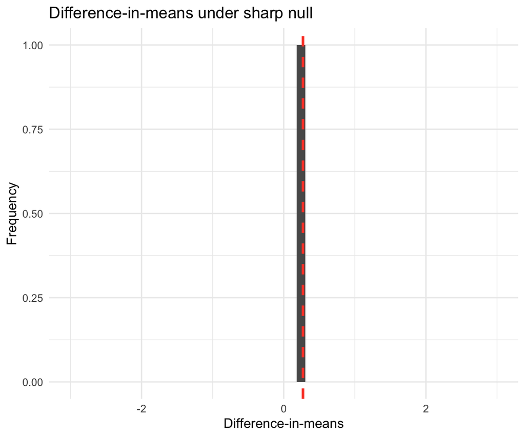

## Permutation 2

| Participant ID | $Z$ (Invited to protest) | $Y$ (Support for policies) | $Y (0)$ (Support for policies if not invited) | $Y (1)$ (Support for policies if invited) |
| --- | --- | --- | --- | --- |
| 1 | 1 | 0.859 | 0.859 | 0.859 |
| 2 | 0 | 1.930 | 1.93 | 1.93 |
| 3 | 1 | 0.875 | 0.875 | 0.875 |
| 4 | 0 | 2.944 | 2.944 | 2.944 |
| 5 | 0 | -1.015 | -1.015 | -1.015 |
| 6 | 1 | -0.064 | -0.064 | -0.064 |
| 7 | 1 | 1.624 | 1.624 | 1.624 |
| 8 | 0 | -0.411 | -0.411 | -0.411 |
| 9 | 1 | 1.048 | 1.048 | 1.048 |
| 10 | 0 | -0.282 | -0.282 | -0.282 |

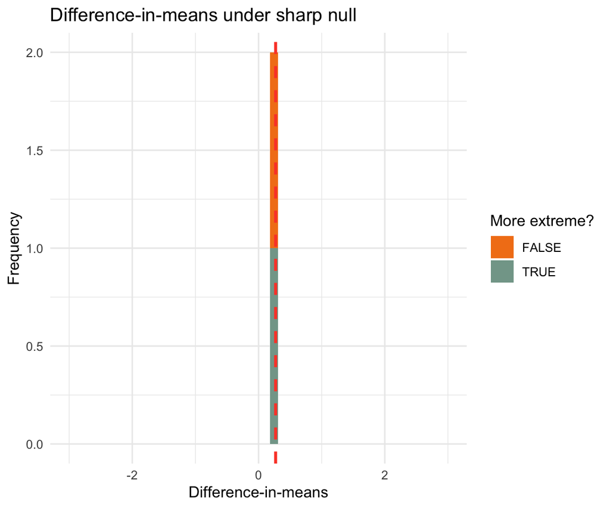

## Permutation 3

| Participant ID | $Z$ (Invited to protest) | $Y$ (Support for policies) | $Y (0)$ (Support for policies if not invited) | $Y (1)$ (Support for policies if invited) |
| --- | --- | --- | --- | --- |
| 1 | 1 | 0.859 | 0.859 | 0.859 |
| 2 | 0 | 1.930 | 1.93 | 1.93 |
| 3 | 0 | 0.875 | 0.875 | 0.875 |
| 4 | 0 | 2.944 | 2.944 | 2.944 |
| 5 | 0 | -1.015 | -1.015 | -1.015 |
| 6 | 1 | -0.064 | -0.064 | -0.064 |
| 7 | 1 | 1.624 | 1.624 | 1.624 |
| 8 | 1 | -0.411 | -0.411 | -0.411 |
| 9 | 0 | 1.048 | 1.048 | 1.048 |
| 10 | 1 | -0.282 | -0.282 | -0.282 |

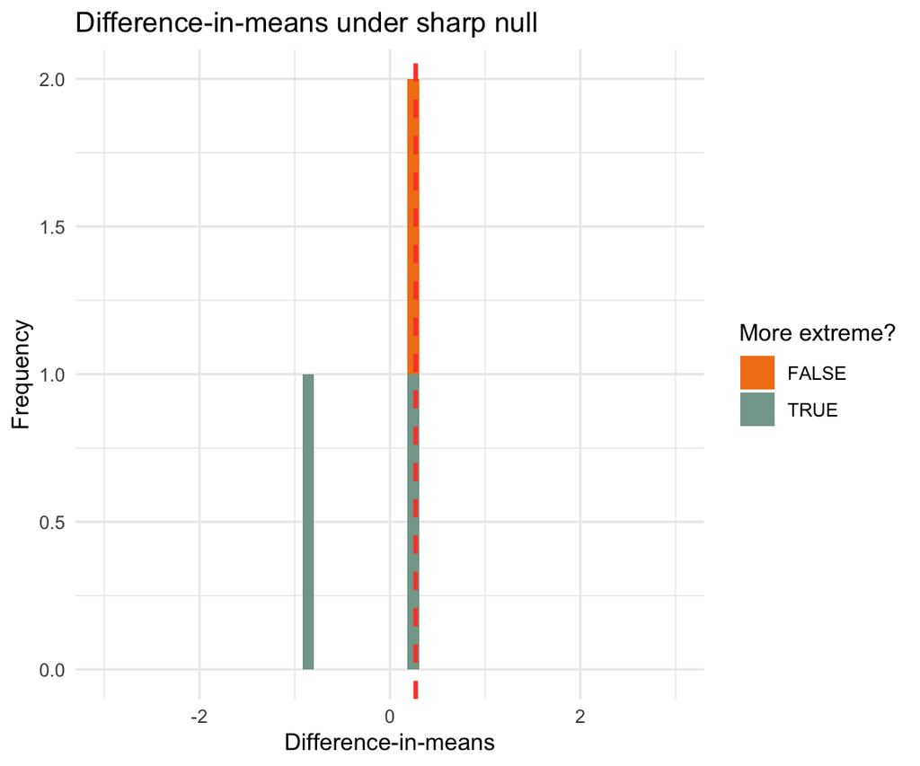

## Permutation 10

| Participant ID | $Z$ (Invited to protest) | $Y$ (Support for policies) | $Y (0)$ (Support for policies if not invited) | $Y (1)$ (Support for policies if invited) |
| --- | --- | --- | --- | --- |
| 1 | 1 | 0.859 | 0.859 | 0.859 |
| 2 | 0 | 1.930 | 1.93 | 1.93 |
| 3 | 1 | 0.875 | 0.875 | 0.875 |
| 4 | 0 | 2.944 | 2.944 | 2.944 |
| 5 | 1 | -1.015 | -1.015 | -1.015 |
| 6 | 0 | -0.064 | -0.064 | -0.064 |
| 7 | 1 | 1.624 | 1.624 | 1.624 |
| 8 | 1 | -0.411 | -0.411 | -0.411 |
| 9 | 0 | 1.048 | 1.048 | 1.048 |
| 10 | 0 | -0.282 | -0.282 | -0.282 |

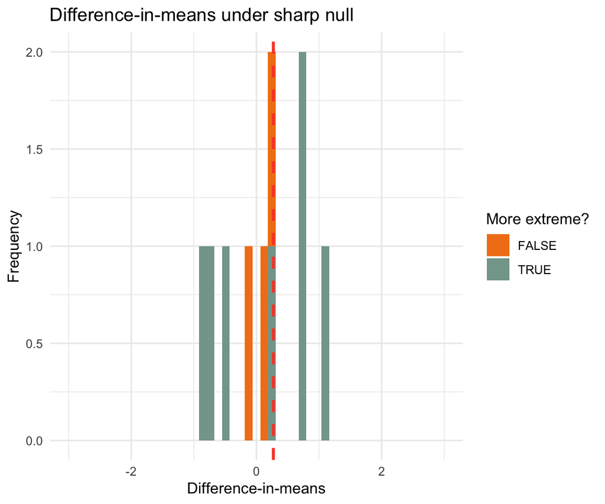

## Permutation 100

| Participant ID | $Z$ (Invited to protest) | $Y$ (Support for policies) | $Y (0)$ (Support for policies if not invited) | $Y (1)$ (Support for policies if invited) |
| --- | --- | --- | --- | --- |
| 1 | 0 | 0.859 | 0.859 | 0.859 |
| 2 | 1 | 1.930 | 1.93 | 1.93 |
| 3 | 1 | 0.875 | 0.875 | 0.875 |
| 4 | 0 | 2.944 | 2.944 | 2.944 |
| 5 | 1 | -1.015 | -1.015 | -1.015 |
| 6 | 1 | -0.064 | -0.064 | -0.064 |
| 7 | 0 | 1.624 | 1.624 | 1.624 |
| 8 | 1 | -0.411 | -0.411 | -0.411 |
| 9 | 0 | 1.048 | 1.048 | 1.048 |
| 10 | 0 | -0.282 | -0.282 | -0.282 |

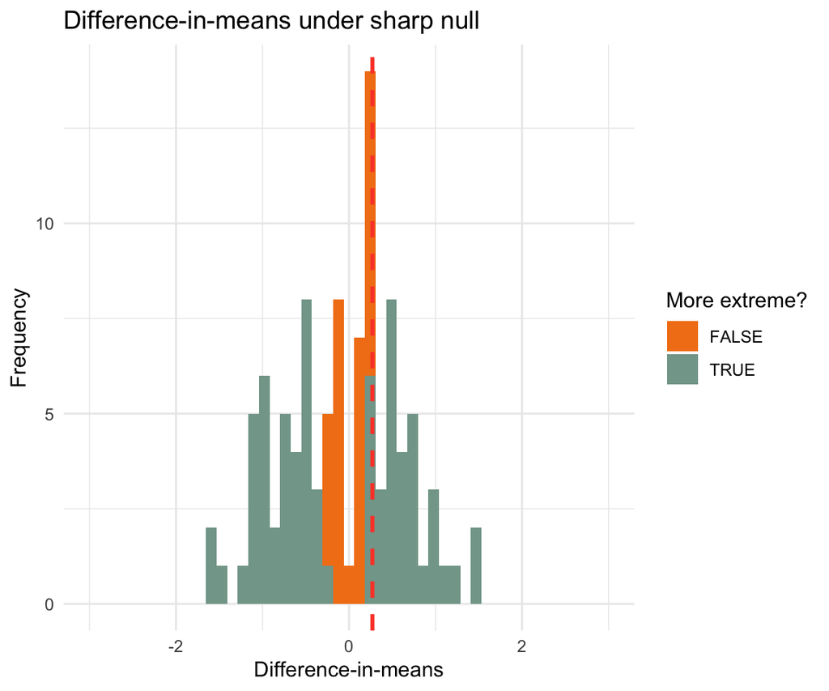

## Permutation 1000

| Participant ID | $Z$ (Invited to protest) | $Y$ (Support for policies) | $Y (0)$ (Support for policies if not invited) | $Y (1)$ (Support for policies if invited) |
| --- | --- | --- | --- | --- |
| 1 | 1 | 0.859 | 0.859 | 0.859 |
| 2 | 0 | 1.930 | 1.93 | 1.93 |
| 3 | 1 | 0.875 | 0.875 | 0.875 |
| 4 | 1 | 2.944 | 2.944 | 2.944 |
| 5 | 0 | -1.015 | -1.015 | -1.015 |
| 6 | 0 | -0.064 | -0.064 | -0.064 |
| 7 | 0 | 1.624 | 1.624 | 1.624 |
| 8 | 1 | -0.411 | -0.411 | -0.411 |
| 9 | 1 | 1.048 | 1.048 | 1.048 |
| 10 | 0 | -0.282 | -0.282 | -0.282 |

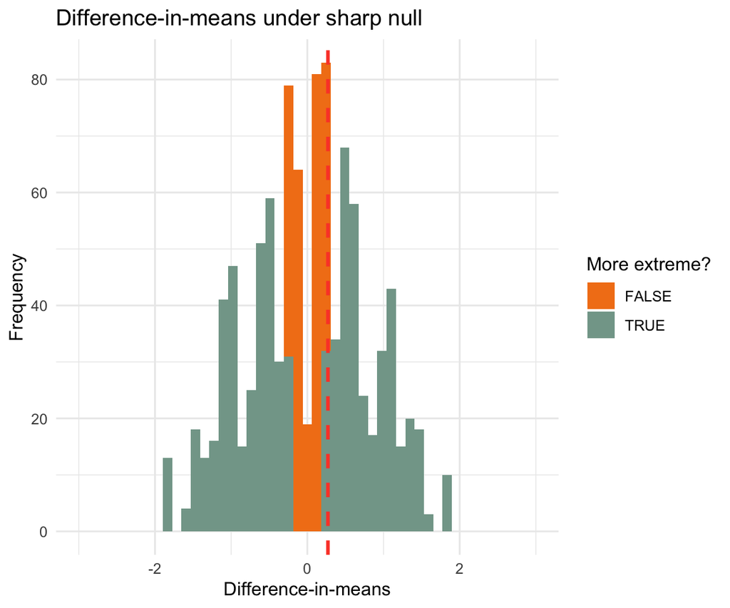

## Permutation 10000

| Participant ID | $Z$ (Invited to protest) | $Y$ (Support for policies) | $Y (0)$ (Support for policies if not invited) | $Y (1)$ (Support for policies if invited) |
| --- | --- | --- | --- | --- |
| 1 | 0 | 0.859 | 0.859 | 0.859 |
| 2 | 1 | 1.930 | 1.93 | 1.93 |
| 3 | 0 | 0.875 | 0.875 | 0.875 |
| 4 | 0 | 2.944 | 2.944 | 2.944 |
| 5 | 0 | -1.015 | -1.015 | -1.015 |
| 6 | 1 | -0.064 | -0.064 | -0.064 |
| 7 | 1 | 1.624 | 1.624 | 1.624 |
| 8 | 1 | -0.411 | -0.411 | -0.411 |
| 9 | 0 | 1.048 | 1.048 | 1.048 |
| 10 | 1 | -0.282 | -0.282 | -0.282 |

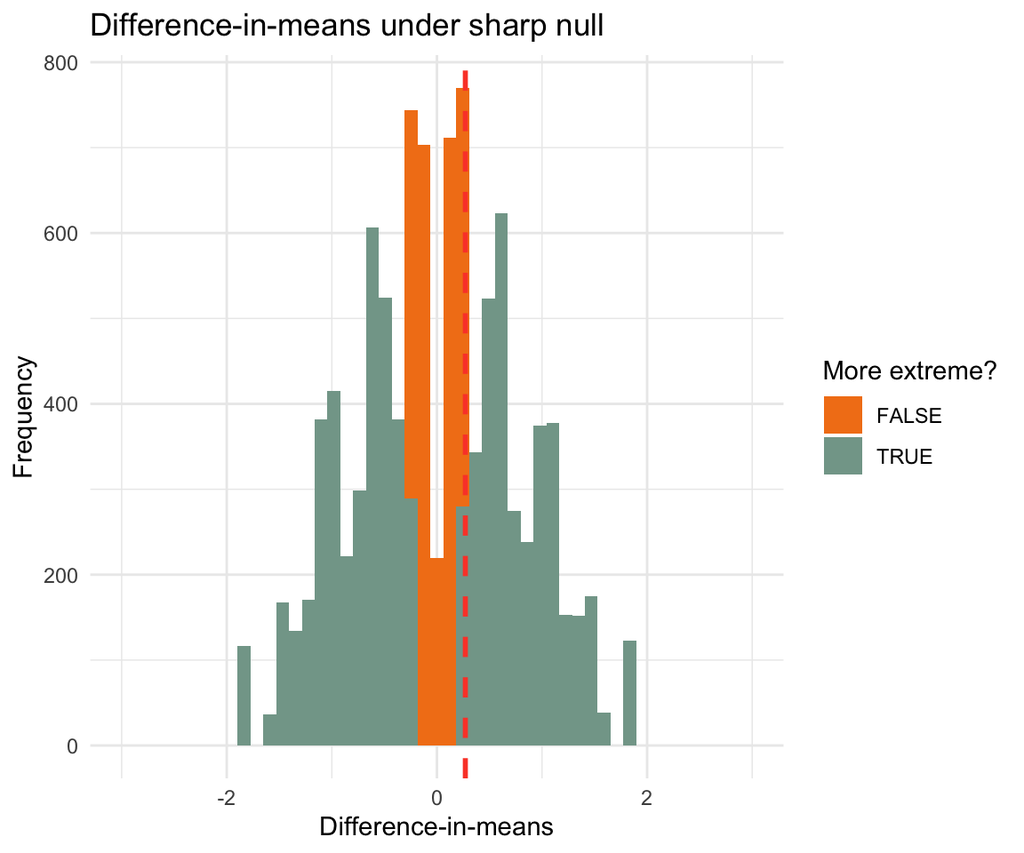

- **What conclusion do we make?**

## Resulting $p$-values are similar!

```r
Z <- c(1    , 1    , 1    , 0    , 0.    , 0.    , 0.   , 0.    , 1.   , 1)

Y <- c(0.859, 1.930, 0.875, 2.944, -1.015, -0.064, 1.624, -0.411, 1.048, -0.282)
```

**Under CLT:**

```r
dim_observed <- mean(Y[Z == 1]) - mean(Y[Z == 0])

se <-
  sqrt(
    var(Y[Z == 1])/length(Y[Z == 1]) +
      var(Y[Z == 0])/length(Y[Z == 0])
  )

c(estimate = dim_observed,
  p.value = 2 * pnorm(q = abs(dim_observed), mean = 0, sd = se, lower.tail = FALSE))
```

```
 estimate   p.value
0.2704000 0.7382426
```

**OLS:**

```r
stats::lm(Y ~ Z) |>
  summary() |>
  broom::tidy() |>
  dplyr::filter(term == "Z") |>
  dplyr::select(estimate, p.value)
```

```
# A tibble: 1 × 2
  estimate p.value
     <dbl>   <dbl>
1    0.270   0.747
```

**Randomization inference:**

```r
dim_observed <- mean(Y[Z == 1]) - mean(Y[Z == 0])

dim_simulated <-
  base::replicate(1000, {
    Z_simulated <- sample(Z)
    mean(Y[Z_simulated == 1]) - mean(Y[Z_simulated == 0])
  })

c(estimate = dim_observed,
  p.value = mean(abs(dim_simulated) >= abs(dim_observed)))
```

```
estimate  p.value
  0.2704   0.7430
```

# Testing errors and false-positives

## Testing errors

- A $p$-value of $0.05$ says that data this extreme would only happen in 5% of repeated samples if the null were true.
  - In other words **our test results by definition are not always correct!**
  - 5% of the time we’ll reject the null when it is actually true.
- Test results vs reality:

|  | $H_0$ is True | $H_0$ is False |
| --- | --- | --- |
| $H_0$ is not Rejected | Great! | **Type II error** |
| $H_0$ is Rejected | **Type I error** | Amazing! |

- Type I error (**False-positive**) is the worst: Like convicting an innocent
- Type II error (**False negative**) is less serious: Missed out on an awesome finding

## What are the threats of these errors?

- The more tests we conduct the higher are chances to reject $H_0$ in favor of $H_1$ at least once
  - Multiple comparisons adjustment: use lower $p$-values threshold as you increase number of hypothesis tests
- The significant results could be driven by other factors
  - Replication the results of the study can address this
  - **Study replication**: Repeating a study using new data
  - **Data analysis replication**: Conducting data analysis using the same data
  - **Rerunning the code**

## Protzko et al. (2024)

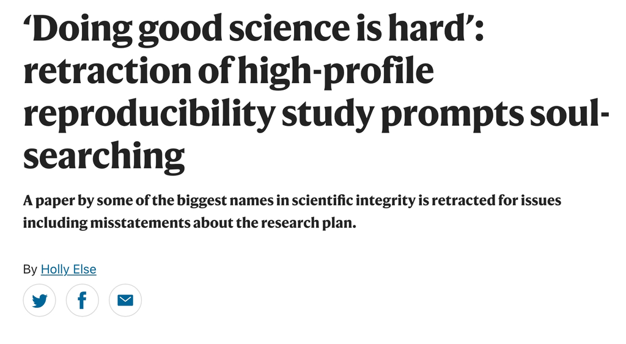

## Breznau et al. (2022)

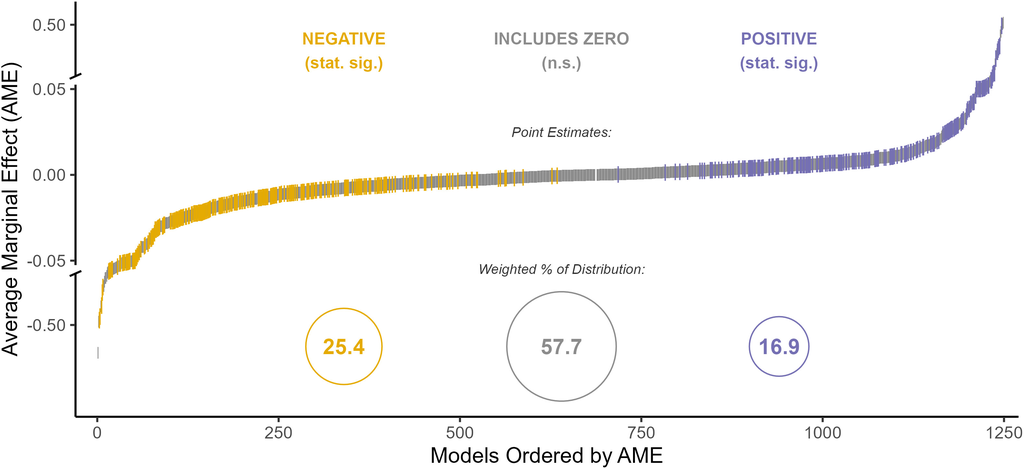

*Will different researchers converge on similar findings when analyzing the same data? Seventy-three independent research teams used identical cross-country survey data to test a prominent social science hypothesis: that more immigration will reduce public support for government provision of social policies. Instead of convergence, teams’ results varied greatly, ranging from large negative to large positive effects of immigration on social policy support. The choices made by the research teams in designing their statistical tests explain very little of this variation; a hidden universe of uncertainty remains. Considering this variation, scientists, especially those working with the complexities of human societies and behavior, should exercise humility and strive to better account for the uncertainty in their work.*

## College sports 🏈 and elections 🗳️

- *Irrelevant events affect voters’ evaluations of government performance* by Healy, Malhotra, and Mo (2010)
- Summary:
  - Previous research finds that natural disasters and other unpredictable events have an effect on incumbent politicians’ support
  - Authors argue that even events completely unrelated to politics can have an effect on incumbent’s support
  - Consider case of college footbal and basketball games
  - Mix of observational and survey experimental evidence
  - Several robustness excercises

## Digging into argument

- Should we expect events unrelated to politics to have an effect on voting?
  - Do government investments and response matter?
  - Do psychological factros matter?
  - What else could matter?
- Let’s break into groups and then draw a possible causal diagram

## Study 1: College Football and Elections

- What are the dependent and independent variables?
- How are those operationalized?
- What are the tests they are running?
- Why do they need so many tests?

## Controls

- What does it mean to *control* for the factors (covariates) in estimation? Why would we do that?
- We control for the factors to *remove the variation in dependent variable that is explained by them*
  - This allows us to say that the part of variation we explain with our independent variable is not explained by the factor
  - In other words this addresses possibility that the factor is confounder (i.e. causes both independent and dependent variables)
- Common controls: Demographics, lagged outcomes, *fixed effects*, etc.

## Robustness and Placebo tests

- What is robustness test?
- Idea is to subset or append data to be able to run the test of the same expectation
  - Re-running analyses with covariates counts as robustness test
  - Each additional test that supports our theory increases our confidence in that theory
- What is placebo? And what is placebo test?
- Purpose of placebo test is to show that the variables do not vary with the factors irrelevant to our theory
  - Variant 1: Irrelevant independent variable does not predict outcome
  - Variant 2: Independent variable does not predict irrrelevant outcomes

## Evidence

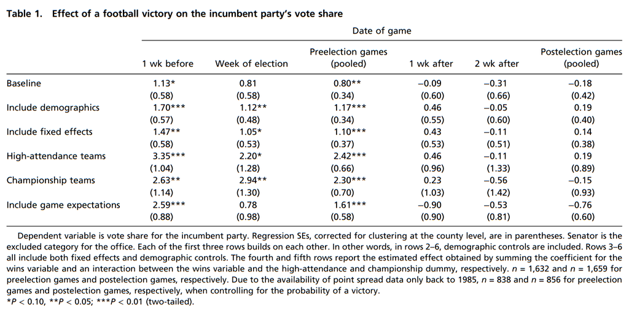

## Study 2: Survey experiment

- What are the dependent and independent variables?
- How are those operationalized?
- What are the tests they are running?
  - And why do we need to run this?

## Evidence

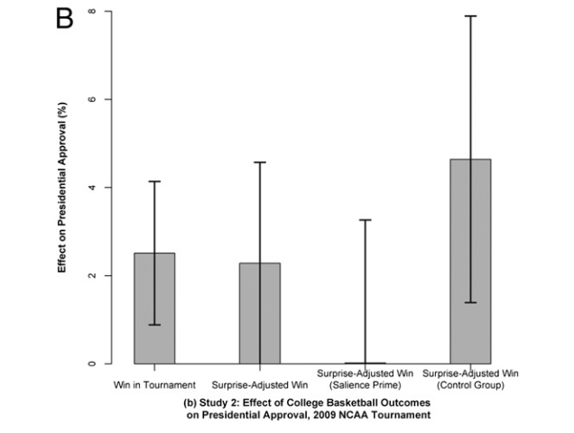

## Story of false-positives 😱

- *College football, elections, and false-positive results in observational research* by Fowler and Montagnes (2015)

Summary:

- Healy, Malhotra, and Mo (2010) did a great job and the paper had been influential, **BUT**
- …Their results could have been produced by chance (spurious correlation) $\Rightarrow$ **False-positive**
- Approach is to take similar data and run additional robustness checks (akin to replication of experiment)
- Additional robustness checks fail to support original theory

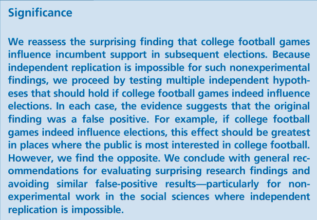

## How do they show this

- What is dependent and independent variables? How are they operationalized?
- What tests do they run? Why do they run the same regression initially?

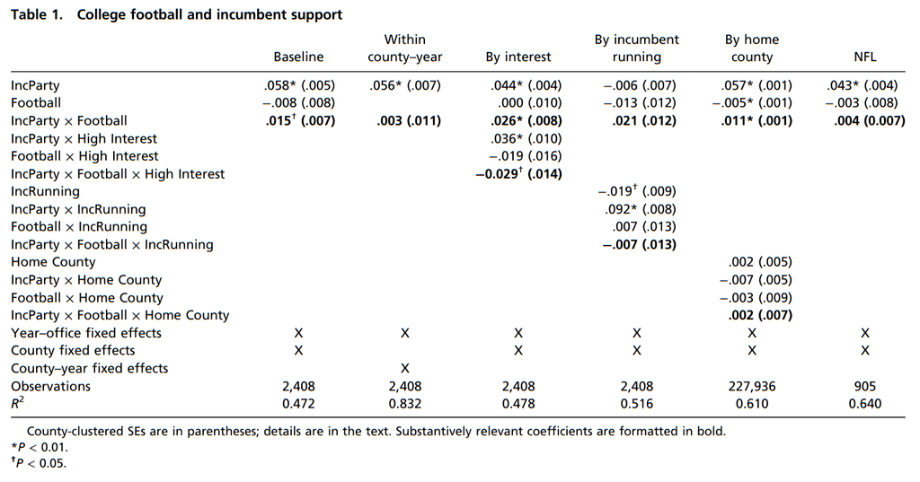

## How do they explain these results

- Fowler and Montagnes (2015) acknowledge that Healy, Malhotra, and Mo (2010) also ran robustness/placebo tests, **BUT**:
1. Placebo tests do not provide evidence against false-positive
2. Including controls (demographics and fixed effects) is not fully independent test and cannot guard against false-positive
3. Explanation about why effects 10 days before would be stronger than 3 days before could suggest ex-post theory adjustment (wow…)
4. They run multiple tests of each hypothesis but do not adjust for **multiple comparisons** (Bonferroni correction)
5. Championships are bad proxy for interest and fail to replicate high-attendance results,

💀⚰️⏹️

## Broader implications for research design

- Think about all possible implications of theory and see if you can test them with your or other available data
  - This is especially important for observational studies
- Operationalization of variables is crucial!
- If you run many tests of the same hypothesis you need to adjust for *multiple comparisons* since you can come up with significant results just by chance

## References

Breznau, Nate, Eike Mark Rinke, Alexander Wuttke, Hung HV Nguyen, Muna Adem, Jule Adriaans, Amalia Alvarez-Benjumea, et al. 2022. “Observing Many Researchers Using the Same Data and Hypothesis Reveals a Hidden Universe of Uncertainty.” *Proceedings of the National Academy of Sciences* 119 (44): e2203150119.

Fowler, Anthony, and B. Pablo Montagnes. 2015. “College Football, Elections, and False-Positive Results in Observational Research.” *Proceedings of the National Academy of Sciences* 112 (45): 13800–13804. https://doi.org/10.1073/pnas.1502615112.

Healy, Andrew J., Neil Malhotra, and Cecilia Hyunjung Mo. 2010. “Irrelevant Events Affect Voters’ Evaluations of Government Performance.” *Proceedings of the National Academy of Sciences* 107 (29): 1280412809.

Protzko, John, Jon Krosnick, Leif Nelson, Brian A Nosek, Jordan Axt, Matt Berent, Nicholas Buttrick, et al. 2024. “High Replicability of Newly Discovered Social-Behavioural Findings Is Achievable.” *Nature Human Behaviour* 8 (2): 311–19.